# Johansen_Van_Topic_1

### Part 1 - Tools Readiness

Install Python 3.7 (or later) and PyCharm

Add the following libraries: Numpy, Pandas, Matplotlib, and Scikit-Learn

Create simple Jupyter notebooks, in which you import the four packages and write minimal Python scripts demonstrating that all libraries have been installed correctly. You may copy examples from the quickstart tutorials for each one of these libraries:

https://docs.scipy.org/doc/numpy/user/quickstart.html

https://pandas.pydata.org/pandas-docs/stable/getting_started/

https://matplotlib.org/users/pyplot_tutorial.html

https://elitedatascience.com/python-machine-learning-tutorial-scikit-learn

NOTE: Occasionally, links to packages and manuals change. If you get a broken link, navigate one level up on the respective sites, where the package is located, and look for the link to the reference manual.

#### Part 2 - Review Predictive Models and Python Proficiency

Consider the task of calculating the appreciation of a real estate property over time. Using concepts from previous courses (e.g., linear regression, predictive modeling), create a model to predict the future value of the property using at least three different input variables. You have the freedom to decide what these variables are. Show the following:

1. The mathematical model using formal mathematical notation
2. An explanation of all variables used
3. An implementation of the model in Python (as a Jupyter notebook), including relevant visual output (e.g., graphs)

What factors influence the quality of predictions? Discuss these factors and measure the change in outcome when these factors are modified. Estimate the error in your model, both mathematically and in code.

Your computer program should produce a clear quantitative result, error estimate, and a plot that visualizes the prediction.

Create a private GitHub or Bitbucket repository (you may already have one from a previous class). Then, create a directory for this class and sub-directories for each topic assignments.

Create a README.md file in which you list all the files that make up your submission and the necessary instructions to run the code.

Upload the Python Jupyter notebooks to your repository and submit the link to LoudCloud.

### Part 3 - Technical Report

Refer to the readings in this topic (textbook and the article "The Seven Tools of Causal Inference, with Reflections on Machine Learning,” which describe:

1. Four forms of learning (supervised, unsupervised, reinforcement, evolutionary)
2. Four learning tasks (classification, regression, learning association, clustering)
3. Seven tools of causal inference

Examine the article “Using Machine Learning to Translate Applicant Work History into Predictors of Performance and Turnover.” Write a two-page technical report covering the following:

Characterize the article in terms of the forms of learning, learning tasks, and causal inference it reports.

Defend your characterization by mapping the concepts onto the specific details mentioned or inferred in the article.

Use the GCU digital library to find work describing a form of learning or learning task that is not covered by the categories listed in Part 1. Use your findings to expand your characterization in (2).

### PART 1

```
the following is a numpy array:
[[ 0  1  2  3  4]
 [ 5  6  7  8  9]
 [10 11 12 13 14]]


the following is a pandas dataframe:
                       Name  Age     Sex
0   Braund, Mr. Owen Harris   22    male
1  Allen, Mr. William Henry   35    male
2  Bonnell, Miss. Elizabeth   58  female


the following is a plot from Matplotlib:
```

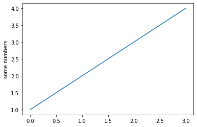

```python
import numpy as np
import pandas as pd
import matplotlib.pyplot as plt
import seaborn as sns
from sklearn.datasets import load_boston
from sklearn.model_selection import train_test_split
from sklearn.linear_model import LinearRegression
from sklearn.metrics import mean_squared_error, r2_score, accuracy_score
import statsmodels.api as sm

%matplotlib inline

a = np.arange(15).reshape(3, 5)
print('the following is a numpy array:')
print(a)
print("\n")
df = pd.DataFrame({
"Name": ["Braund, Mr. Owen Harris",
"Allen, Mr. William Henry",
"Bonnell, Miss. Elizabeth"],
"Age": [22, 35, 58],
"Sex": ["male", "male", "female"]}
)
print('the following is a pandas dataframe:')
print(df.head())
print("\n")

print('the following is a plot from Matplotlib:')
plt.plot([1, 2, 3, 4])
plt.ylabel('some numbers')
plt.show()
```

```python
boston_dataset = load_boston()

boston = pd.DataFrame(boston_dataset.data, columns=boston_dataset.feature_names)
boston['MEDV'] = boston_dataset.target

print('the following is a dataset from Sklearn:')
boston.head()
```

```
the following is a dataset from Sklearn:
```

|  | CRIM | ZN | INDUS | CHAS | NOX | RM | AGE | DIS | RAD | TAX | PTRATIO | B | LSTAT | MEDV |
| --- | --- | --- | --- | --- | --- | --- | --- | --- | --- | --- | --- | --- | --- | --- |
| 0 | 0.00632 | 18.0 | 2.31 | 0.0 | 0.538 | 6.575 | 65.2 | 4.0900 | 1.0 | 296.0 | 15.3 | 396.90 | 4.98 | 24.0 |
| 1 | 0.02731 | 0.0 | 7.07 | 0.0 | 0.469 | 6.421 | 78.9 | 4.9671 | 2.0 | 242.0 | 17.8 | 396.90 | 9.14 | 21.6 |
| 2 | 0.02729 | 0.0 | 7.07 | 0.0 | 0.469 | 7.185 | 61.1 | 4.9671 | 2.0 | 242.0 | 17.8 | 392.83 | 4.03 | 34.7 |
| 3 | 0.03237 | 0.0 | 2.18 | 0.0 | 0.458 | 6.998 | 45.8 | 6.0622 | 3.0 | 222.0 | 18.7 | 394.63 | 2.94 | 33.4 |
| 4 | 0.06905 | 0.0 | 2.18 | 0.0 | 0.458 | 7.147 | 54.2 | 6.0622 | 3.0 | 222.0 | 18.7 | 396.90 | 5.33 | 36.2 |

### PART 2

Data Dictionary:

CRIM - per capita crime rate by town

ZN - proportion of residential land zoned for lots over 25,000 sq.ft.

INDUS - proportion of non-retail business acres per town.

CHAS - Charles River dummy variable (1 if tract bounds river; 0 otherwise)

NOX - nitric oxides concentration (parts per 10 million)

RM - average number of rooms per dwelling

AGE - proportion of owner-occupied units built prior to 1940

DIS - weighted distances to five Boston employment centres

RAD - index of accessibility to radial highways

TAX - full-value property-tax rate per $10,000

PTRATIO - pupil-teacher ratio by town

B - proportion of blacks by town

LSTAT - Percent lower status of the population

MEDV - Median value of owner-occupied homes in $1000's

```python
# Data preprocessing - check for missing values
boston.isnull().sum()
```

```
CRIM       0
ZN         0
INDUS      0
CHAS       0
NOX        0
RM         0
AGE        0
DIS        0
RAD        0
TAX        0
PTRATIO    0
B          0
LSTAT      0
MEDV       0
dtype: int64
```

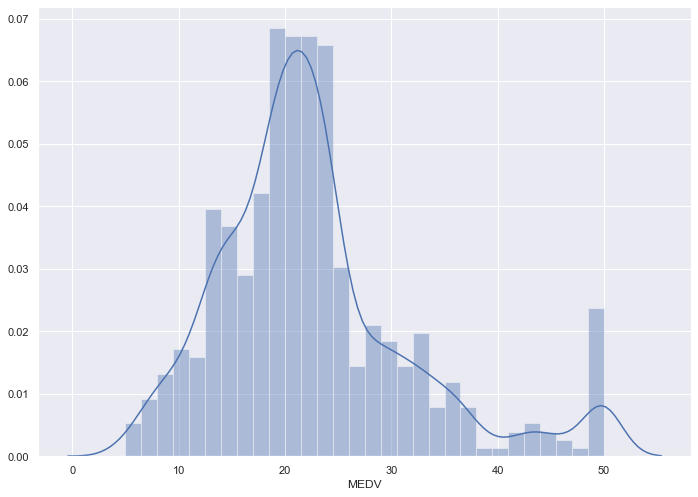

```python
# EDA
sns.set(rc={'figure.figsize':(11.7,8.27)})
sns.distplot(boston['MEDV'], bins=30)
plt.show()
# target variable is distributed normally - although there are some outliers at the high end
```

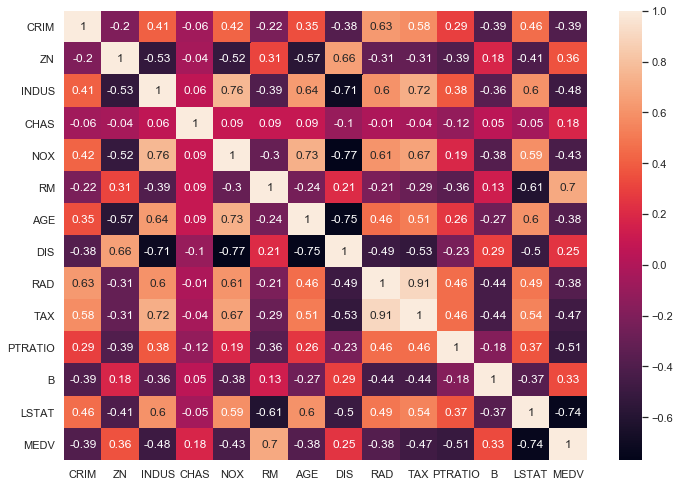

```python
correlation_matrix = boston.corr().round(2)
# annot = True to print the values inside the square
sns.heatmap(data=correlation_matrix, annot=True)

# checking for correlation between variables

# LSTAT and RM are correlated with the target variable
```

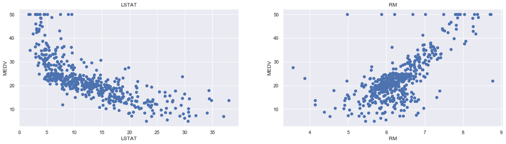

```python
# plot the two features that are highly correlated with target variable
plt.figure(figsize=(20, 5))

features = ['LSTAT', 'RM']
target = boston['MEDV']

for i, col in enumerate(features):
    plt.subplot(1, len(features) , i+1)
    x = boston[col]
    y = target
    plt.scatter(x, y, marker='o')
    plt.title(col)
    plt.xlabel(col)
    plt.ylabel('MEDV')
```

```python
# set up dataframe going into the model
X = pd.DataFrame(np.c_[boston['LSTAT'], boston['RM']], columns = ['LSTAT','RM'])
Y = boston['MEDV']
```

```python
# split data for a training and testing set
X_train, X_test, Y_train, Y_test = train_test_split(X, Y, test_size = 0.2, random_state=5)
print(X_train.shape)
print(X_test.shape)
print(Y_train.shape)
print(Y_test.shape)
```

```
(404, 2)
(102, 2)
(404,)
(102,)
```

```python
# build linear regression model
lin_model = LinearRegression()
lin_model.fit(X_train, Y_train)
```

```
LinearRegression(copy_X=True, fit_intercept=True, n_jobs=None, normalize=False)
```

```python
# model evaluation for training set
y_train_predict = lin_model.predict(X_train)
rmse = (np.sqrt(mean_squared_error(Y_train, y_train_predict)))
r2 = r2_score(Y_train, y_train_predict)

print("The model performance for training set")
print("--------------------------------------")
print('RMSE is {}'.format(rmse.round(2)))
print('R2 score is {}'.format(r2.round(2)))
print("\n")

# model evaluation for testing set
y_test_predict = lin_model.predict(X_test)
rmse = (np.sqrt(mean_squared_error(Y_test, y_test_predict)))
r2 = r2_score(Y_test, y_test_predict)

print("The model performance for testing set")
print("--------------------------------------")
print('RMSE is {}'.format(rmse.round(2)))
print('R2 score is {}'.format(r2.round(2)))
```

```
The model performance for training set
--------------------------------------
RMSE is 5.64
R2 score is 0.63


The model performance for testing set
--------------------------------------
RMSE is 5.14
R2 score is 0.66
```

```python
# Fit and summarize OLS model
X = sm.add_constant(X)
ols_mod = sm.OLS(Y, X)
ols_fit = ols_mod.fit()
print(ols_fit.summary())
```

```
                            OLS Regression Results
==============================================================================
Dep. Variable:                   MEDV   R-squared:                       0.639
Model:                            OLS   Adj. R-squared:                  0.637
Method:                 Least Squares   F-statistic:                     444.3
Date:                Wed, 09 Sep 2020   Prob (F-statistic):          7.01e-112
Time:                        20:30:46   Log-Likelihood:                -1582.8
No. Observations:                 506   AIC:                             3172.
Df Residuals:                     503   BIC:                             3184.
Df Model:                           2
Covariance Type:            nonrobust
==============================================================================
                 coef    std err          t      P>|t|      [0.025      0.975]
------------------------------------------------------------------------------
const         -1.3583      3.173     -0.428      0.669      -7.592       4.875
LSTAT         -0.6424      0.044    -14.689      0.000      -0.728      -0.556
RM             5.0948      0.444     11.463      0.000       4.222       5.968
==============================================================================
Omnibus:                      145.712   Durbin-Watson:                   0.834
Prob(Omnibus):                  0.000   Jarque-Bera (JB):              457.690
Skew:                           1.343   Prob(JB):                    4.11e-100
Kurtosis:                       6.807   Cond. No.                         202.
==============================================================================

Warnings:
[1] Standard Errors assume that the covariance matrix of the errors is correctly specified.
```

### Model Summary/Report

###### Why did I choose this model type?

I chose this model because the data was all numeric, and the target variable can be easily determined and modeled by an Ordinary Least Squares model. As certain variables increase or decrease, they have influence on the target variable of home price. From the assigned book for this course, the author explains "the training examples follow a distribution similar to that of future patterns (unseen by the machine during training) which the machine will receive; the machine will be required to give estimated output values ˆy for these patterns. If the training experience consists of data that lies in a region of the state space, then that region must be fully representative of situations over which the trained machine will later be used" (Gopal, p.47).

###### What is the mathematical Formula?

For OLS model the mathematical formula follows this pattern:

Y=Xβ+μ, where μ∼N(0,Σ)

In this example we can input our results and we get the following:

Y = -0.642X1 + 5.095X2 - 1.358

(with X1 being the LSTAT variable and X2 being the RM variable)

###### What other methods could have been used for future iterations?

If I were to continue the analysis and try a new modeling method, I would test out a LASSO Regression. It is similar to an OLS method, however, it utilizes shrinkage. Shrinkage is where data values are shrunk towards a central point, like the mean. The lasso procedure encourages simple, sparse models (i.e. models with fewer parameters). This particular type of regression is well-suited for models showing high levels of muticollinearity or when you want to automate certain parts of model selection, like variable selection/parameter elimination (Brownlee, 2019).

###### What are the variables used and their relationships?

In this model I chose to use the variables Rooms per House and Percent Lower Status of Population. These two variables have the highest correlation with the price of the house, target variable, as seen in the correlation matrix above. From the plots we can see as the number of rooms increase the price of the house increases and as the percent of lower status population decreases the price of the house increases.

###### What is the estimated error?

The estimated error for the model - on the training set was 5.64 and the testing set was 5.14

###### What are the key factors and their influence?

There are several factors that could have been used in the model, and in a future iterations I could test models with different factors and even try a LASSO model. From the correlation matrix we can see which factors have the most influence on our target variable of house price. As we already established, RM and LSTAT are the most highly influencial factors, however; other factors that could have high influence are PTRATIO and INDUS (pupil-teacher ratio by town and proportion of non-retail business acres per town).

### References

Brownlee, J. (2020, August 20). Supervised and Unsupervised Machine Learning Algorithms. Retrieved from https://machinelearningmastery.com/supervised-and-unsupervised-machine-learning-algorithms/

Brownlee, J. (2019, November 10). 14 Different Types of Learning in Machine Learning. Retrieved from https://machinelearningmastery.com/types-of-learning-in-machine-learning/

Gopal, M. (2019). Applied machine learning. New York: McGraw-Hill Education.

Pearl, J. (2019). The Seven Tools of Causal Inference, with Reflections on Machine Learning. Communications of the ACM, 62(3), 54–60. https://doi-org.lopes.idm.oclc.org/10.1145/3241036

Sajjadiani, S., Sojourner, A. J., Kammeyer-Mueller, J. D., & Mykerezi, E. (2019). Using machine learning to translate applicant work history into predictors of performance and turnover. Journal of Applied Psychology, 104(10), 1207–1225. https://doi-org.lopes.idm.oclc.org/10.1037/apl0000405

Talabis, M. M. (2015). Supervised Learning. Retrieved from https://www.sciencedirect.com/topics/computer-science/supervised-learning